# MachineLearningSupervised

Umair Waseem

2022-10-05

## Machine Learning Supervised

Machine learning concerns learning from data. You do not explicitly develop an algorithm for solving a particular problem. You use a generic algorithm and let it learn how to solve the problem from those.

## Supervised Learning

- Supervised learning is used when you have variables you want to predict using other variables–situations like linear regression where you have some input variables for example x and you want a model that predicts output variables y =f(x)

## Logistic Regression (Classification)

Here We’ll use the breast cancer data from the mlbench library. Ask if the clump thickness has an effect on the risk of a tumor being malignant. That is we want to see if we can predict the *Class* variable from C1.

```r
library(mlbench)
library(dplyr)
library(tidyverse)
data("BreastCancer")
BreastCancer |> head()
```

```
##        Id Cl.thickness Cell.size Cell.shape Marg.adhesion Epith.c.size
## 1 1000025            5         1          1             1            2
## 2 1002945            5         4          4             5            7
## 3 1015425            3         1          1             1            2
## 4 1016277            6         8          8             1            3
## 5 1017023            4         1          1             3            2
## 6 1017122            8        10         10             8            7
##   Bare.nuclei Bl.cromatin Normal.nucleoli Mitoses     Class
## 1           1           3               1       1    benign
## 2          10           3               2       1    benign
## 3           2           3               1       1    benign
## 4           4           3               7       1    benign
## 5           1           3               1       1    benign
## 6          10           9               7       1 malignant
```

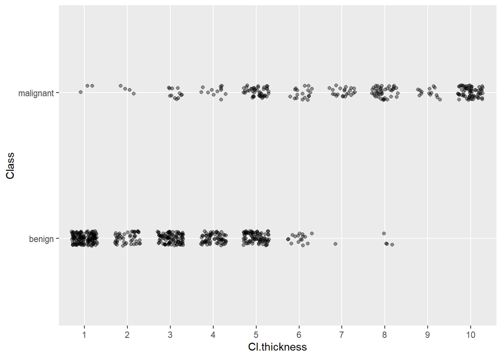

```r
BreastCancer |>
  ggplot (aes(x=Cl.thickness, y = Class)) +
  geom_jitter(height = 0.05, width = 0.3, alpha = 0.4)
```

For classification, We still specify the prediction function y=f(x) using the formula y`x is just binary now. To fi a logistic regression, we need to use the *glm()* function (generalized linear model) with family set to “binomial”. We cannot fit the breast cancer data with logistic regression. There are two problems:- * The breast cancer data set considers the clump thickness order factor, but for logistic regression, we need the input variable to be numeric.. Generally it is not advised to directly translate categorical data into numeric data, but here for this data we can. * The *glm()* function expects the response variable to be numerical, coding the classes like 0 or 1, while the breast cancer data again encodes the classes as a factor. It little varies from algorithm to algorithm whether a factor or a numerical encoding is expected for classification.

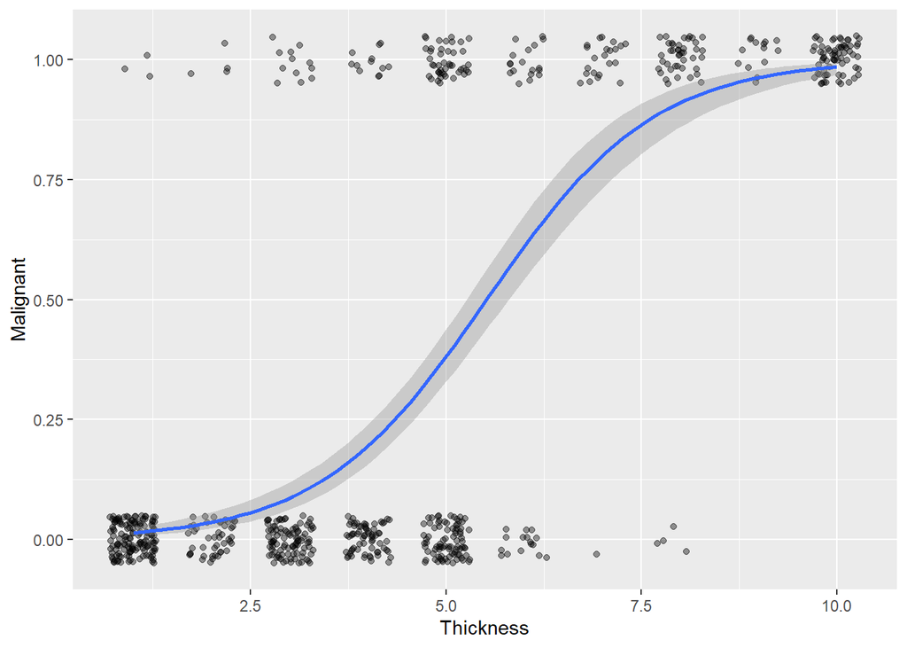

```r
BreastCancer |>
  mutate(Thickness =
           as.numeric(as.character(Cl.thickness))) |>
  mutate(Malignant = ifelse(Class != "benign", 1, 0)) |>
  ggplot(aes(x = Thickness, y = Malignant)) +
  geom_jitter(height = 0.05, width = 0.3, alpha = 0.4) +
  geom_smooth(method ="glm", formula = y~x,
              method.args = list(family = "binomial"))
```

```r
BreastCancer |>
  mutate(Thickness =
           as.numeric(as.character(Cl.thickness))) %>%
  mutate(Malignant = ifelse(Class != "benign", 1, 0)) %>%
  glm(Malignant ~ Thickness,
      family = "binomial",
      data = .)
```

```
##
## Call:  glm(formula = Malignant ~ Thickness, family = "binomial", data = .)
##
## Coefficients:
## (Intercept)    Thickness
##     -5.1602       0.9355
##
## Degrees of Freedom: 698 Total (i.e. Null);  697 Residual
## Null Deviance:       900.5
## Residual Deviance: 464.1     AIC: 468.1
```

```r
# glm(response ~ predictor, family = "binomial", data)
# The glm() funciton returens a model object, therefore we may apply extroactro functions, such as summay, fited(), or predict() among others. Please not that output numbers are on the logit scale. To actually predict probabilities we need ot provided the predict() function an additional argument _type = "response"_
```